# PRA 2. Limpieza y análisis de datos

# 1 Descripción del dataset.

El dataset elegido corresponde al generado en la PRAC1. El dataset contiene los resultados obtenidos por distintos equipos profesionales de fútbol en diversas competiciones a lo largo de la última década.

Nos serviremos de estos datos para anlizar los diferentes clubs de futbol a nivel global así como para buscar patrones entre ellos.

```r
df <- read.csv(file = 'football_competitions.csv')
head(df)
```

|  | competition | pl_team | pl_pi | pl_w | pl_d | pl_l | pl_f | pl_a | pl_gd | pl_pts |
| --- | --- | --- | --- | --- | --- | --- | --- | --- | --- | --- |
| 1 | African Nations - Group A 2008 | Ghana * | 3 | 3 | 0 | 0 | 5 | 1 | 4 | 9 |
| 2 | African Nations - Group A 2008 | Guinea * | 3 | 1 | 1 | 1 | 5 | 5 | 0 | 4 |
| 3 | African Nations - Group A 2008 | Morocco * | 3 | 1 | 0 | 2 | 7 | 6 | 1 | 3 |
| 4 | African Nations - Group A 2008 | Namibia * | 3 | 0 | 1 | 2 | 2 | 7 | -5 | 1 |
| 5 | African Nations - Group B 2008 | Ivory Coast * | 3 | 3 | 0 | 0 | 8 | 1 | 7 | 9 |
| 6 | African Nations - Group B 2008 | Nigeria * | 3 | 1 | 1 | 1 | 2 | 1 | 1 | 4 |

```r
str(df)
```

```
## 'data.frame':    6623 obs. of  10 variables:
##  $ competition: Factor w/ 825 levels "Africa Cup of Nations - Group A 2010",..: 19 19 19 19 20 20 20 20 21 21 ...
##  $ pl_team    : Factor w/ 993 levels "1. FC Union Berlin",..: 398 419 616 624 493 643 579 103 298 172 ...
##  $ pl_pi      : int  3 3 3 3 3 3 3 3 3 3 ...
##  $ pl_w       : int  3 1 1 0 3 1 1 0 2 2 ...
##  $ pl_d       : int  0 1 0 1 0 1 1 0 1 0 ...
##  $ pl_l       : int  0 1 2 2 0 1 1 3 0 1 ...
##  $ pl_f       : int  5 5 7 2 8 2 1 1 8 10 ...
##  $ pl_a       : int  1 5 6 7 1 1 3 7 3 5 ...
##  $ pl_gd      : int  4 0 1 -5 7 1 -2 -6 5 5 ...
##  $ pl_pts     : int  9 4 3 1 9 4 4 0 7 6 ...
```

El fichero contiene una tabla con diez columnas, siendo las dos primeras de tipo cadena y el resto de tipo entero.

Los campos son:

- competition: Nombre de la competición, año y grupo dentro de los cuales el equipo indicado obtuvo los resultados indicados.
- pl_team: Nombre del equipo.
- pl_pi: Número de partidos jugados.
- pl_w: Número de partidos ganados.
- pl_d: Número de partidos empatados.
- pl_l: Número de partidos perdidos.
- pl_f: Número de goles a favor.
- pl_a: Número de goles en contra.
- pl_gd: Diferencia de goles.
- pl_pts: Puntos obtenidos por el equipo.

# 2 Integración y selección de los datos de interés a analizar

# 3 Limpieza de datos

## 3.1 Elementos vacíos y cero.

Primero vamos a ver si hay valores vacíos en el dataset.

```r
sum(is.na(df))
```

```
## [1] 0
```

No hay, buscamos valores 0.

```r
sum(df==0)
```

```
## [1] 4384
```

Hay muchos datos que son igual a cero. Debido a la naturaleza del dataframe no es necesario quitarlos, porque puede ser que un equipo tenga 0 puntos, victorias, derrotas, etc.

## 3.2 Valores extremos.

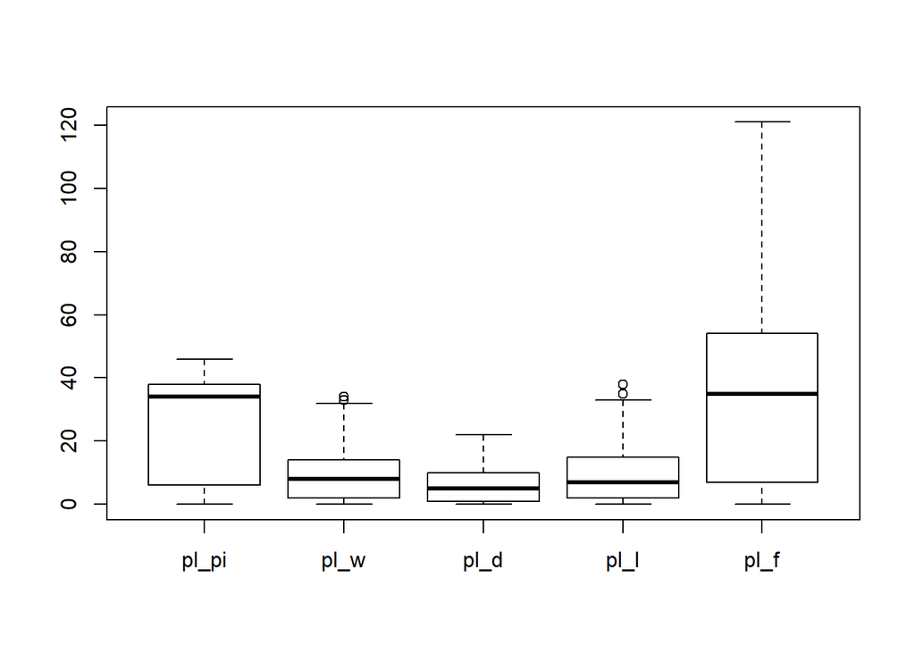

```r
boxplot(df[3:7])
```

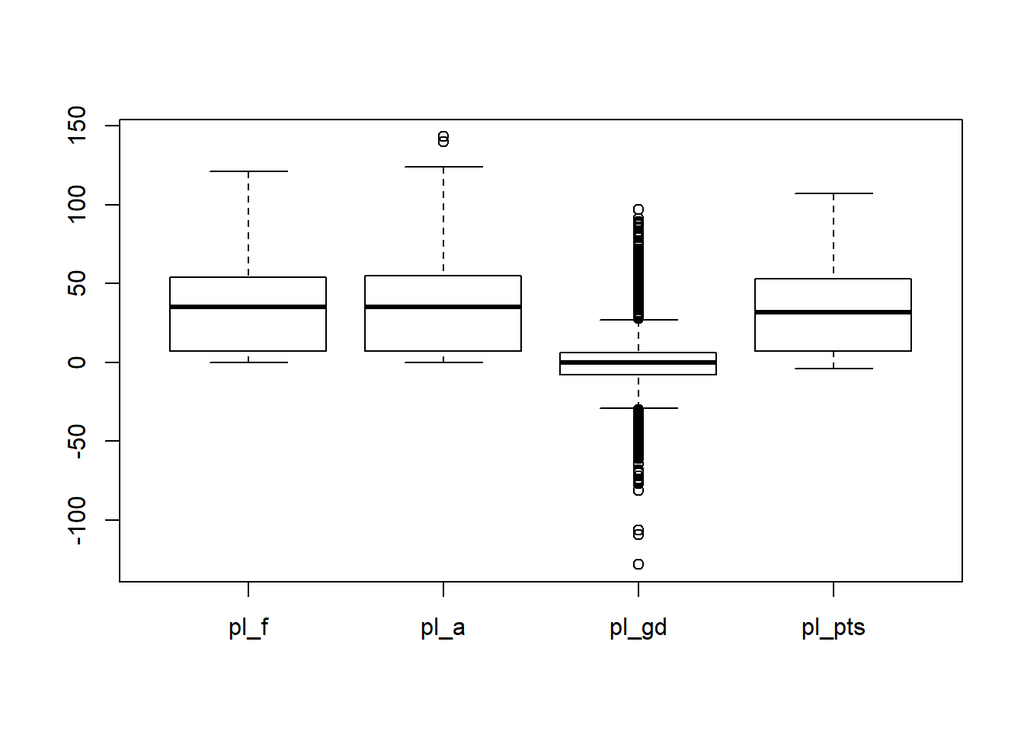

```r
boxplot(df[7:10])
```

# 4 Análisis de los datos.

## 4.1 Selección de los grupos de datos que se quieren analizar/comparar (planificación de los análisis a aplicar).

## 4.2 Comprobación de la normalidad y homogeneidad de la varianza.

## 4.3 Aplicación de pruebas estadísticas para comparar los grupos de datos. En función de los datos y el objetivo del estudio, aplicar pruebas de contraste de hipótesis, correlaciones, regresiones, etc. Aplicar al menos tres métodos de análisis diferentes.

# 5 Representación de los resultados a partir de tablas y gráficas.

# 6 Resolución del problema. A partir de los resultados obtenidos, ¿cuáles son las conclusiones? ¿Los resultados permiten responder al problema?